# BCM Simulation Results

Caitlin Ward

## Gelman Rubin

Number of models remaining with Gelman Rubin > 1.1.

```
## , ,  = 14
##
##
##          betat spline thresh
##   hill       8      5      0
##   power      5      0      0
##   thresh    14      3      0
##
## , ,  = 30
##
##
##          betat spline thresh
##   hill       9      3      0
##   power      1      6      0
##   thresh     9     25      1
```

## Posterior parameter estimates

When correct parametric model was fit to the true data generation process.

### Threshold Alarm

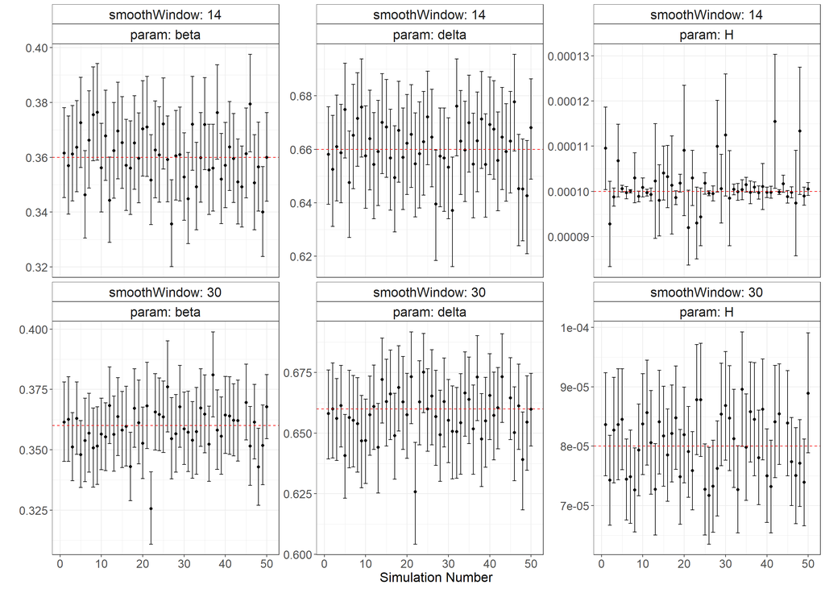

### Hill Alarm

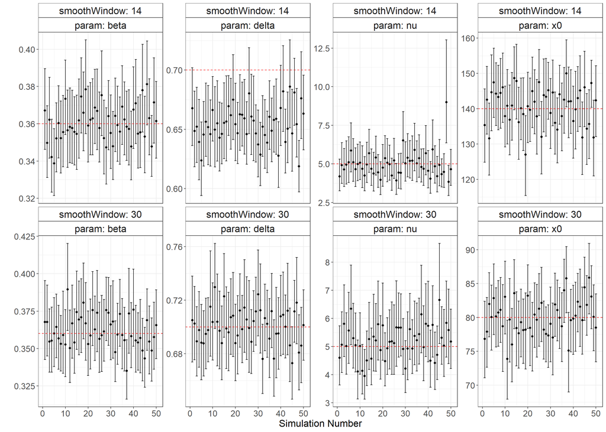

### Power Alarm

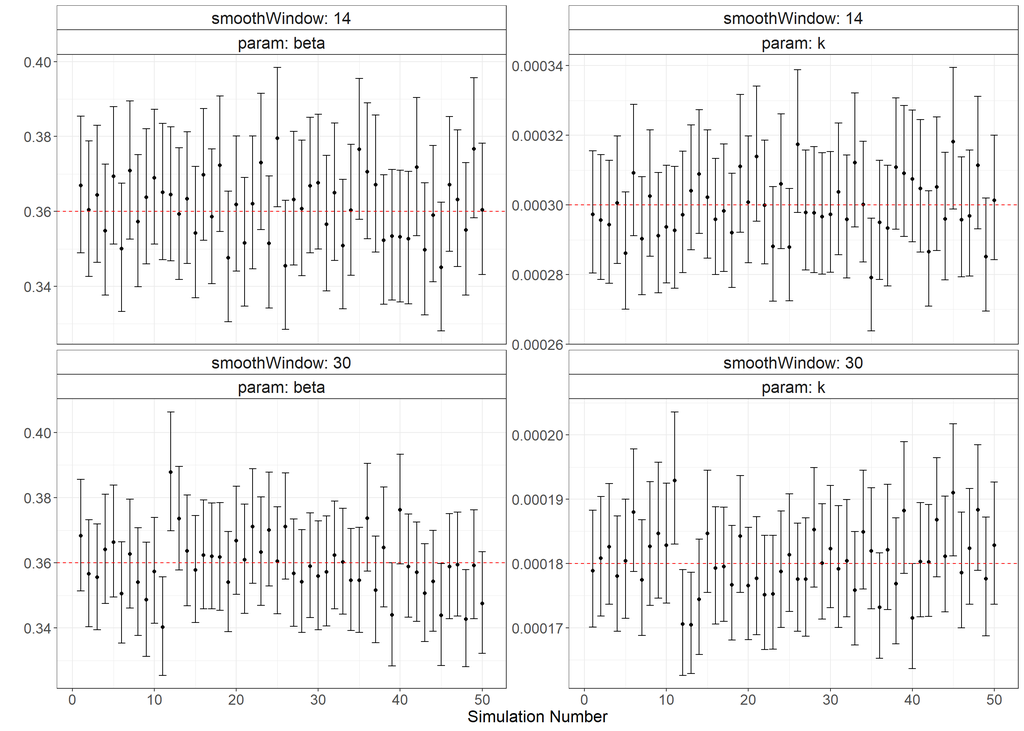

## Posterior for Alarm Function

### 14-day Smoothing Window

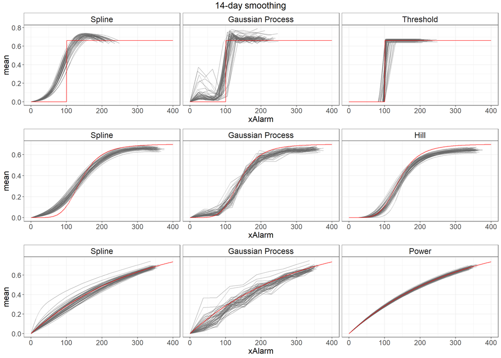

### 30-day Smoothing Window

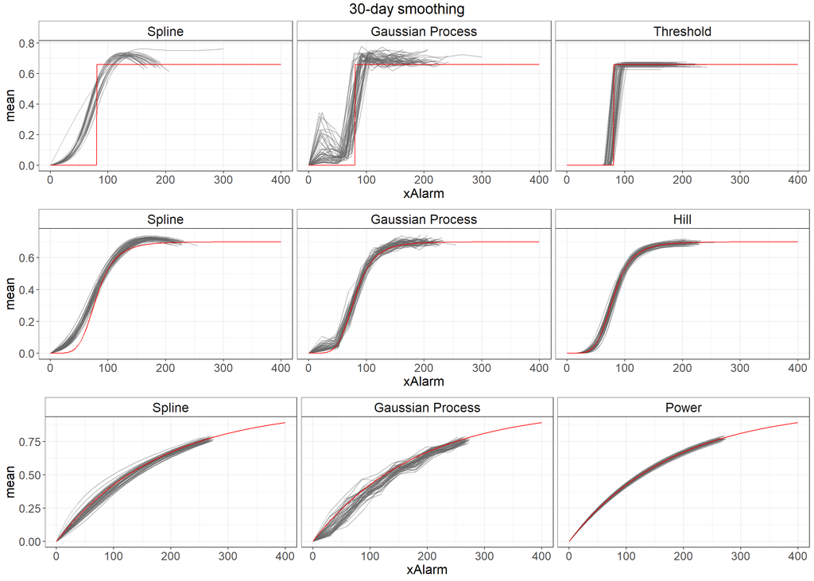

## Posterior prediction

Difficult to look at for every simulated epidemic. Shown here for first epidemic from each scenario.

### 14-day Smoothing Window

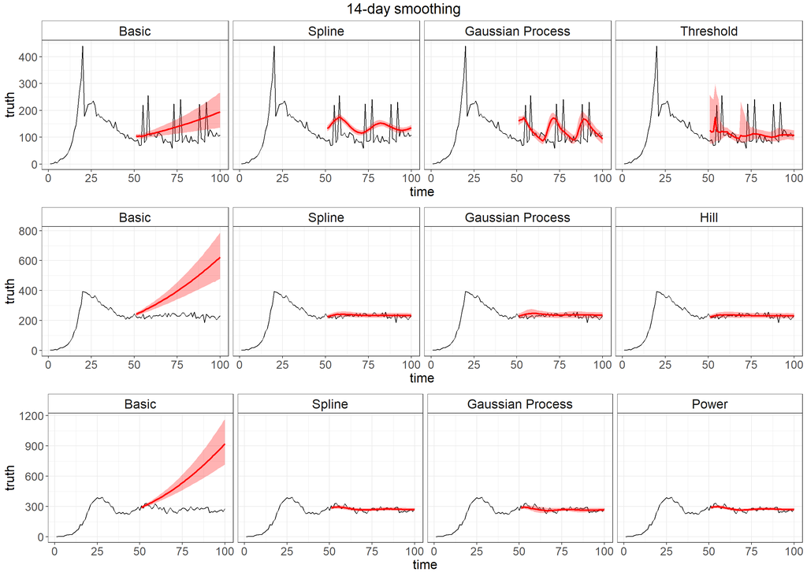

### 30-day Smoothing Window

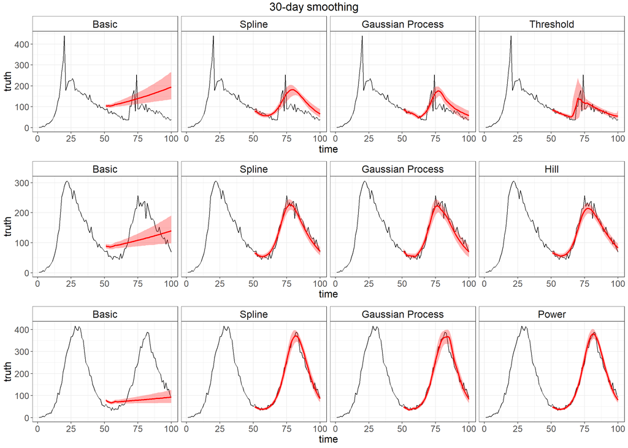

Now for second simulated epidemic

### 14-day Smoothing Window

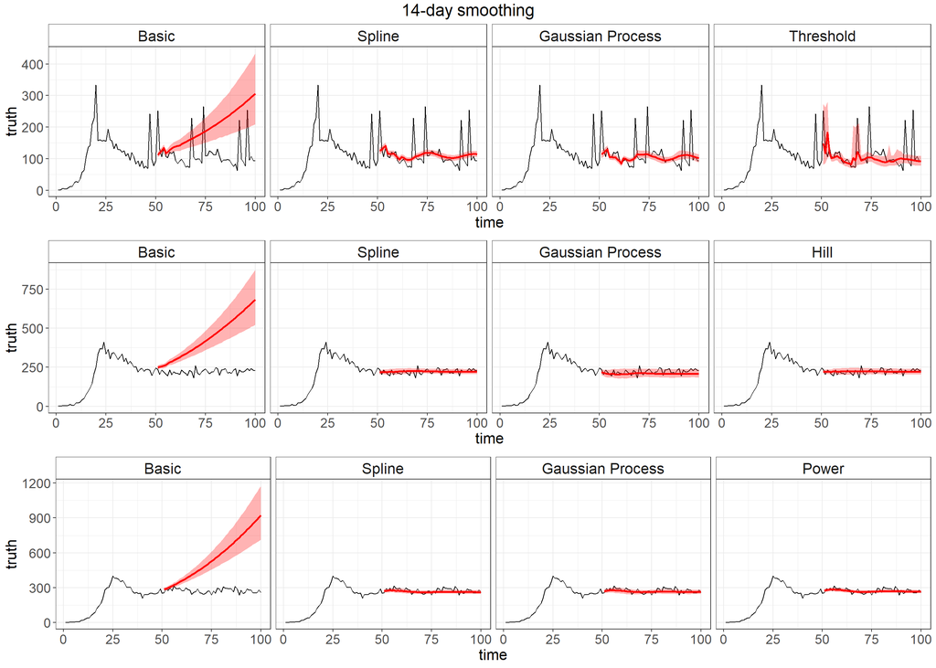

### 30-day Smoothing Window

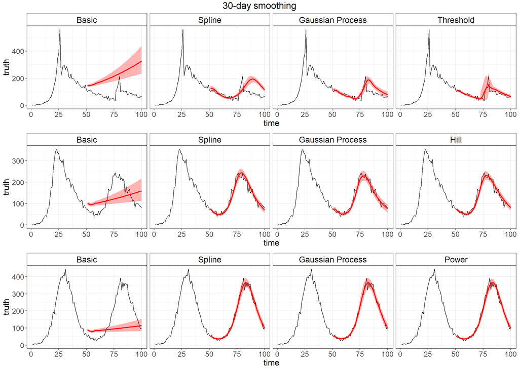

## Posterior for beta[t] when modeled explicitly

For one simulation.

$\beta_t = \beta (1 - a_t)$

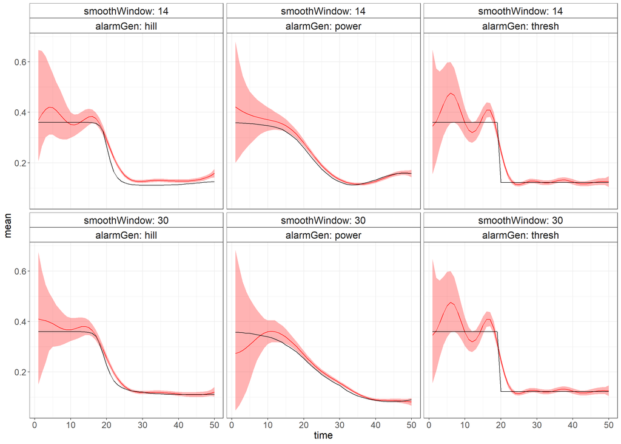

And for another simulation

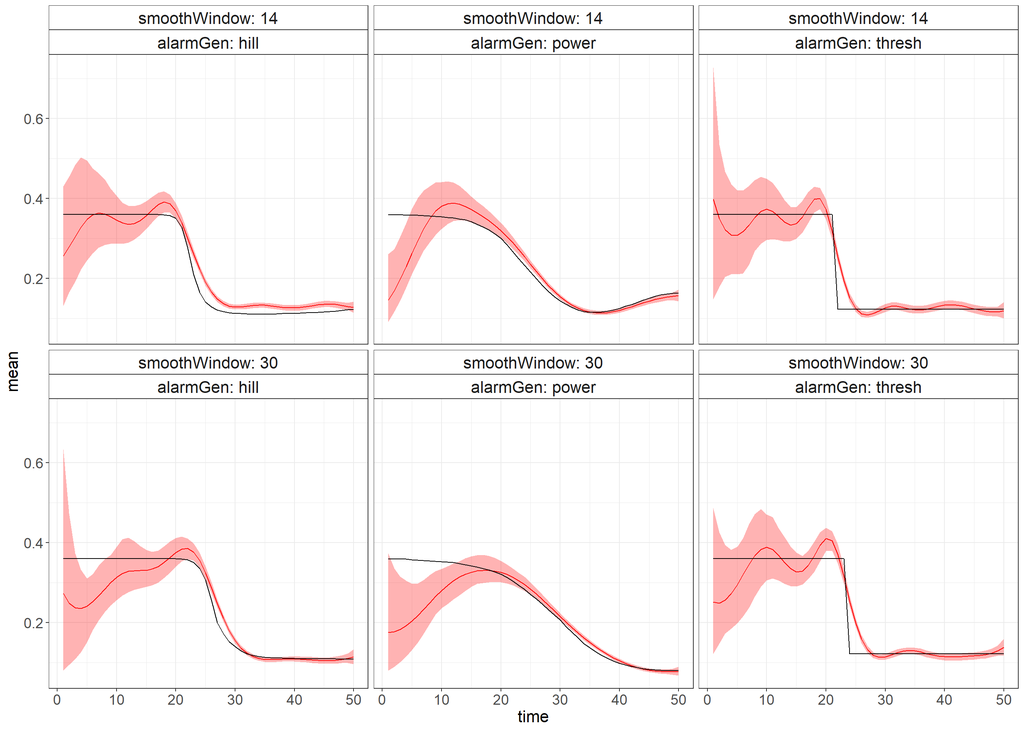

## WAIC comparisons

### WAIC Summaries

WAIC (introduced by Watanabe, 2010, who calls it the widely applicable information criterion) is a more fully Bayesian approach for estimating the out-of-sample expectation (2), starting with the computed log pointwise posterior predictive density (5) and then adding a correction for effective number of parameters to adjust for overfitting.

WAIC = -2(lppd - pWAIC)

= -2lppd + 2pWAIC

WAIC: The computed WAIC, on the deviance scale. Smaller values are better when comparing WAIC for two models.

lppd: The log predictive density component of WAIC. Bigger is better.

pWAIC: The pWAIC estimate of the effective number of parameters, computed using the pWAIC2 method of Gelman et al. (2014).

$pWAIC_2 = \sum_{i = 1}^n \text{Var}_{post} \log p(y_i|\theta)$

we compute the posterior variance of the log predictive density for each data point

#### Threshold alarm with 14-day smoothing window

| alarmFit | mean_WAIC | mean_lppd | mean_pWAIC |
| --- | --- | --- | --- |
| thresh | 357.1725 | -176.6377 | 1.948614 |
| gp | 463.6870 | -209.6567 | 22.186821 |
| spline | 571.7528 | -260.6190 | 25.257392 |
| betat | 583.2877 | -230.8669 | 60.776995 |
| basic | 1613.1700 | -775.9195 | 30.665497 |

#### Threshold alarm with 30-day smoothing window

| alarmFit | mean_WAIC | mean_lppd | mean_pWAIC |
| --- | --- | --- | --- |
| thresh | 358.3429 | -177.2552 | 1.916245 |
| gp | 426.9406 | -189.9215 | 23.548851 |
| spline | 525.1689 | -236.1768 | 26.407678 |
| betat | 545.6635 | -224.0649 | 48.766809 |
| basic | 1723.3954 | -827.1959 | 34.501773 |

#### Hill alarm with 14-day smoothing window

| alarmFit | mean_WAIC | mean_lppd | mean_pWAIC |
| --- | --- | --- | --- |
| hill | 380.1178 | -186.2592 | 3.799719 |
| spline | 385.5839 | -188.0669 | 4.725029 |
| gp | 385.7554 | -185.5806 | 7.297057 |
| betat | 403.7774 | -189.8673 | 12.021362 |
| basic | 1665.1634 | -807.9306 | 24.651083 |

#### Hill alarm with 30-day smoothing window

| alarmFit | mean_WAIC | mean_lppd | mean_pWAIC |
| --- | --- | --- | --- |
| hill | 365.1219 | -178.7360 | 3.824949 |
| gp | 370.6977 | -177.6370 | 7.711880 |
| spline | 375.4694 | -182.6823 | 5.052454 |
| betat | 381.4091 | -180.4812 | 10.223328 |
| basic | 1626.2593 | -786.6037 | 26.525963 |

#### Power alarm with 14-day smoothing window

| alarmFit | mean_WAIC | mean_lppd | mean_pWAIC |
| --- | --- | --- | --- |
| power | 374.8793 | -185.5083 | 1.931322 |
| spline | 376.9707 | -184.5361 | 3.949252 |
| betat | 382.8421 | -183.8700 | 7.551038 |
| gp | 383.1567 | -183.7497 | 7.828650 |
| basic | 1385.0838 | -671.6628 | 20.879057 |

#### Power alarm with 30-day smoothing window

| alarmFit | mean_WAIC | mean_lppd | mean_pWAIC |
| --- | --- | --- | --- |
| power | 366.2396 | -181.1508 | 1.969038 |
| spline | 367.4123 | -179.6533 | 4.052823 |
| betat | 376.0389 | -179.9437 | 8.075768 |
| gp | 376.0561 | -179.5266 | 8.501518 |
| basic | 1871.3591 | -902.8449 | 32.834652 |

### WAIC Model Selection

#### 14-day smoothing window

|  | thresh | hill | power |
| --- | --- | --- | --- |
| thresh | 100.0% | 0.0% | 0.0% |
| hill | 0.0% | 90.0% | 0.0% |
| power | 0.0% | 0.0% | 78.0% |
| gp | 0.0% | 4.0% | 10.0% |
| spline | 0.0% | 4.0% | 8.0% |
| betat | 0.0% | 2.0% | 4.0% |
| basic | 0.0% | 0.0% | 0.0% |

#### 30-day smoothing window

|  | thresh | hill | power |
| --- | --- | --- | --- |
| thresh | 98.0% | 0.0% | 0.0% |
| hill | 0.0% | 86.0% | 0.0% |
| power | 0.0% | 0.0% | 86.0% |
| gp | 2.0% | 6.0% | 2.0% |
| spline | 0.0% | 6.0% | 10.0% |
| betat | 0.0% | 2.0% | 2.0% |
| basic | 0.0% | 0.0% | 0.0% |